# **Project Name** - **PaisaBazar**

##### **Project Type** - EDA/Regression/Classification/Unsupervised

##### **PROJECT HANDLE BY** - **AKHILESH M. BHAGAT**

# **Project Summary -**

**The dataset under analysis contains financial and demographic information of customers, including variables such as Age, Occupation, Annual Income, Monthly Inhand Salary, Number of Bank Accounts, Credit Mix, Outstanding Debt, Credit Utilization Ratio, Credit History Age, EMI, Investment, Payment Behaviour, Monthly Balance, and Credit Score. To better understand the dataset, relationships between variables were explored using 15 different visualization techniques. These visualizations not only highlight individual variable patterns but also reveal correlations and trends across multiple factors that influence a customer’s financial profile and credit score.**

**The Age distribution histogram revealed that the majority of customers fall between the 20–40 year age range, which represents the working-age group. This indicates that the dataset primarily consists of young adults who are either starting their careers or are in the early stages of financial independence. The boxplot of Annual Income showed the spread of income across the customers and highlighted the presence of outliers, which indicates that while most customers earn within a specific range, a few have extremely high incomes compared to the rest.**

# **GitHub Link -**

GitHub Link :- https://github.com/Akhileshbhagat76/PaisaBazar

# **Problem Statement**

**Financial institutions depend on customer data such as age, income, occupation, outstanding debt, and credit behavior to assess creditworthiness and manage lending risks. However, due to the complexity and volume of such data, it is difficult to extract meaningful insights without proper analysis and visualization**.

**This project focuses on performing Exploratory Data Analysis (EDA) using the given dataset of customer demographics, financial details, and credit scores. By applying 15 different visualization techniques including histograms, scatter plots, heatmaps, and pairplots, the objective is to identify patterns, correlations, and trends among variables. The problem is to understand how different factors—such as income, debt, and credit utilization—affect a customer’s credit score. The outcome will provide clear insights that can support financial institutions in evaluating customer profiles and making informed lending decisions.**

# **Let's Begin !**

## **1. Know Your Data**

### Import Libraries

```python
# Import Libraries

# Data Handling
import pandas as pd

#Preprocessing
from sklearn.preprocessing import LabelEncoder, StandardScaler

# Train-Test Split & CV
from sklearn.model_selection import train_test_split, GridSearchCV, cross_val_score

#  Machine Learning Models
from sklearn.linear_model import LogisticRegression
from sklearn.ensemble import RandomForestClassifier

# Evaluation Metrics
from sklearn.metrics import accuracy_score, classification_report, precision_score, recall_score, f1_score, confusion_matrix

# Visualization
import matplotlib.pyplot as plt
import seaborn as sns

# Model Persistence
import joblib
```

### Dataset Loading

```python
# Load Dataset

import pandas as pd

# Dataset load
df = pd.read_csv("dataset-2.csv")

df.head()
```

|  | ID | Customer_ID | Month | Name | Age | SSN | Occupation | Annual_Income | Monthly_Inhand_Salary | Num_Bank_Accounts | ... | Credit_Mix | Outstanding_Debt | Credit_Utilization_Ratio | Credit_History_Age | Payment_of_Min_Amount | Total_EMI_per_month | Amount_invested_monthly | Payment_Behaviour | Monthly_Balance | Credit_Score |
| --- | --- | --- | --- | --- | --- | --- | --- | --- | --- | --- | --- | --- | --- | --- | --- | --- | --- | --- | --- | --- | --- |
| 0 | 5634 | 3392 | 1 | Aaron Maashoh | 23.0 | 821000265.0 | Scientist | 19114.12 | 1824.843333 | 3.0 | ... | Good | 809.98 | 26.822620 | 265.0 | No | 49.574949 | 21.46538 | High_spent_Small_value_payments | 312.494089 | Good |
| 1 | 5635 | 3392 | 2 | Aaron Maashoh | 23.0 | 821000265.0 | Scientist | 19114.12 | 1824.843333 | 3.0 | ... | Good | 809.98 | 31.944960 | 266.0 | No | 49.574949 | 21.46538 | Low_spent_Large_value_payments | 284.629162 | Good |
| 2 | 5636 | 3392 | 3 | Aaron Maashoh | 23.0 | 821000265.0 | Scientist | 19114.12 | 1824.843333 | 3.0 | ... | Good | 809.98 | 28.609352 | 267.0 | No | 49.574949 | 21.46538 | Low_spent_Medium_value_payments | 331.209863 | Good |
| 3 | 5637 | 3392 | 4 | Aaron Maashoh | 23.0 | 821000265.0 | Scientist | 19114.12 | 1824.843333 | 3.0 | ... | Good | 809.98 | 31.377862 | 268.0 | No | 49.574949 | 21.46538 | Low_spent_Small_value_payments | 223.451310 | Good |
| 4 | 5638 | 3392 | 5 | Aaron Maashoh | 23.0 | 821000265.0 | Scientist | 19114.12 | 1824.843333 | 3.0 | ... | Good | 809.98 | 24.797347 | 269.0 | No | 49.574949 | 21.46538 | High_spent_Medium_value_payments | 341.489231 | Good |

5 rows × 28 columns

### Dataset First View

```python
# Dataset First Look

# Dataset fisrt 5 rows
df.head()

# Dataset last 5 row
df.tail()

# Random 5 rows
df.sample(5)
```

|  | ID | Customer_ID | Month | Name | Age | SSN | Occupation | Annual_Income | Monthly_Inhand_Salary | Num_Bank_Accounts | ... | Credit_Mix | Outstanding_Debt | Credit_Utilization_Ratio | Credit_History_Age | Payment_of_Min_Amount | Total_EMI_per_month | Amount_invested_monthly | Payment_Behaviour | Monthly_Balance | Credit_Score |
| --- | --- | --- | --- | --- | --- | --- | --- | --- | --- | --- | --- | --- | --- | --- | --- | --- | --- | --- | --- | --- | --- |
| 47028 | 76174 | 20897 | 5 | Sakthio | 45.0 | 959746872.0 | Entrepreneur | 63306.54 | 5260.545000 | 4.0 | ... | Standard | 1203.19 | 35.760177 | 337.0 | No | 85.611125 | 79.260419 | Low_spent_Large_value_payments | 455.162051 | Standard |
| 55769 | 89287 | 13616 | 2 | Edwardk | 29.0 | 738747100.0 | Journalist | 43200.90 | 3807.075000 | 8.0 | ... | Bad | 1404.99 | 39.786485 | 136.0 | Yes | 117.833840 | 35.984752 | High_spent_Small_value_payments | 404.504003 | Poor |
| 47652 | 77110 | 33254 | 5 | Dhanya Skariachanb | 21.0 | 990528222.0 | Mechanic | 22728.90 | 1773.075000 | 5.0 | ... | Standard | 888.02 | 40.426376 | 303.0 | Yes | 42.191755 | 30.941994 | High_spent_Medium_value_payments | 348.211874 | Standard |
| 95616 | 149058 | 4588 | 1 | William Schombergh | 34.0 | 417742163.0 | Journalist | 14867.69 | 1005.974167 | 9.0 | ... | Standard | 2344.06 | 37.591597 | 199.0 | Yes | 55.459604 | 17.843996 | Low_spent_Medium_value_payments | 238.348740 | Standard |
| 11037 | 22187 | 28939 | 6 | Vlastelical | 30.0 | 496473679.0 | Doctor | 47958.76 | 3756.563333 | 6.0 | ... | Good | 180.73 | 37.218655 | 339.0 | NM | 93.077430 | 76.925511 | High_spent_Medium_value_payments | 391.422030 | Poor |

5 rows × 28 columns

### Dataset Rows & Columns count

```python
# Dataset Rows & Columns count

# Rows and Columns count
rows, cols = df.shape
print("Total Rows:", rows)
print("Total Columns:", cols)
```

```
Total Rows: 100000
Total Columns: 28
```

### Dataset Information

```python
# Dataset Info

df.info()
```

```
<class 'pandas.core.frame.DataFrame'>
RangeIndex: 100000 entries, 0 to 99999
Data columns (total 28 columns):
 #   Column                    Non-Null Count   Dtype
---  ------                    --------------   -----
 0   ID                        100000 non-null  int64
 1   Customer_ID               100000 non-null  int64
 2   Month                     100000 non-null  int64
 3   Name                      100000 non-null  object
 4   Age                       100000 non-null  float64
 5   SSN                       100000 non-null  float64
 6   Occupation                100000 non-null  object
 7   Annual_Income             100000 non-null  float64
 8   Monthly_Inhand_Salary     100000 non-null  float64
 9   Num_Bank_Accounts         100000 non-null  float64
```

[output cut: 20 more lines]

#### Duplicate Values

```python
# Dataset Duplicate Value Count

duplicates = df.duplicated().sum()
print("Total Duplicate Rows:", duplicates)
```

```
Total Duplicate Rows: 0
```

#### Missing Values/Null Values

```python
# Missing Values/Null Values Count

# column  missing values
missing = df.isnull().sum()
print(missing)

#columns missing values
missing = missing[missing > 0]
print("\nColumns with Missing Values:\n", missing)

# Missing values percentage
missing_percent = (df.isnull().sum() / len(df)) * 100
print("\nMissing Values Percentage:\n", missing_percent[missing_percent > 0])
```

```
ID                          0
Customer_ID                 0
Month                       0
Name                        0
Age                         0
SSN                         0
Occupation                  0
Annual_Income               0
Monthly_Inhand_Salary       0
Num_Bank_Accounts           0
Num_Credit_Card             0
Interest_Rate               0
Num_of_Loan                 0
Type_of_Loan                0
Delay_from_due_date         0
Num_of_Delayed_Payment      0
Changed_Credit_Limit        0
Num_Credit_Inquiries        0
Credit_Mix                  0
Outstanding_Debt            0
Credit_Utilization_Ratio    0
Credit_History_Age          0
Payment_of_Min_Amount       0
Total_EMI_per_month         0
Amount_invested_monthly     0
Payment_Behaviour           0
Monthly_Balance             0
Credit_Score                0
dtype: int64

Columns with Missing Values:
 Series([], dtype: int64)

Missing Values Percentage:
 Series([], dtype: float64)
```

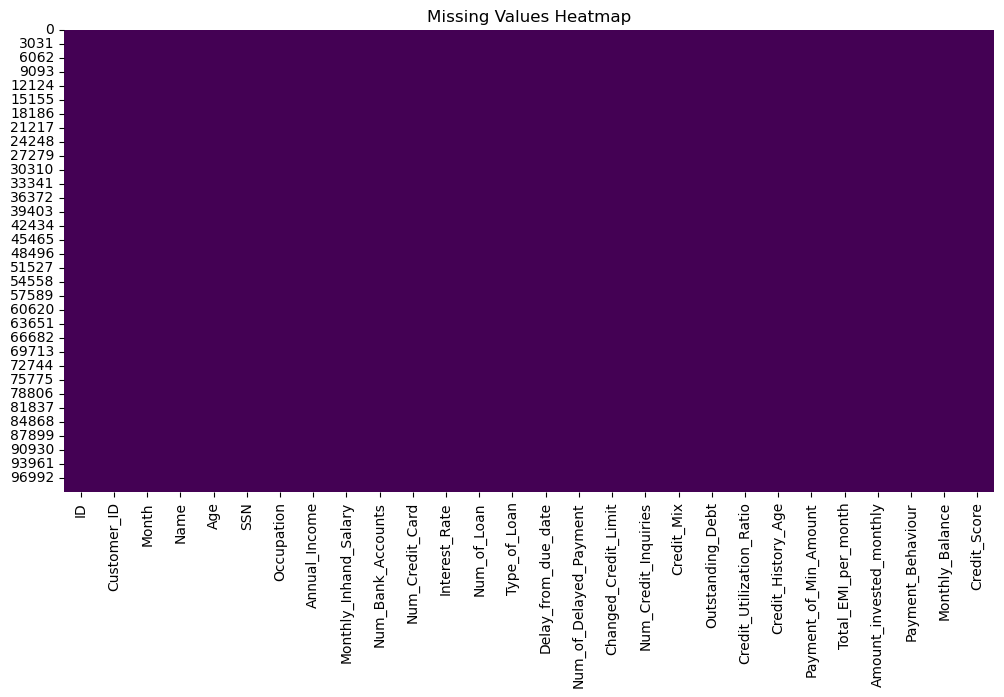

```python
# Visualizing the missing values

import matplotlib.pyplot as plt
import seaborn as sns

# Missing values visualization
plt.figure(figsize=(12,6))
sns.heatmap(df.isnull(), cbar=False, cmap="viridis")
plt.title("Missing Values Heatmap")
plt.show()
```

## **2. Understanding Your Variables**

```python
# Dataset Columns
def variable_summary(df):
    summary = pd.DataFrame({
        "Column": df.columns,
        "DataType": df.dtypes.values,
        "MissingValues": df.isnull().sum().values,
        "UniqueValues": [df[col].nunique() for col in df.columns]
    })
    return summary

# Run this
variable_summary(df)
```

|  | Column | DataType | MissingValues | UniqueValues |
| --- | --- | --- | --- | --- |
| 0 | ID | int64 | 0 | 100000 |
| 1 | Customer_ID | int64 | 0 | 12500 |
| 2 | Month | int64 | 0 | 8 |
| 3 | Name | object | 0 | 10128 |
| 4 | Age | float64 | 0 | 43 |
| 5 | SSN | float64 | 0 | 12500 |
| 6 | Occupation | object | 0 | 15 |
| 7 | Annual_Income | float64 | 0 | 12488 |
| 8 | Monthly_Inhand_Salary | float64 | 0 | 13241 |
| 9 | Num_Bank_Accounts | float64 | 0 | 12 |
| 10 | Num_Credit_Card | float64 | 0 | 12 |
| 11 | Interest_Rate | float64 | 0 | 34 |
| 12 | Num_of_Loan | float64 | 0 | 10 |
| 13 | Type_of_Loan | object | 0 | 6261 |
| 14 | Delay_from_due_date | float64 | 0 | 63 |
| 15 | Num_of_Delayed_Payment | float64 | 0 | 26 |
| 16 | Changed_Credit_Limit | float64 | 0 | 3452 |
| 17 | Num_Credit_Inquiries | float64 | 0 | 18 |
| 18 | Credit_Mix | object | 0 | 3 |
| 19 | Outstanding_Debt | float64 | 0 | 12203 |
| 20 | Credit_Utilization_Ratio | float64 | 0 | 100000 |
| 21 | Credit_History_Age | float64 | 0 | 404 |
| 22 | Payment_of_Min_Amount | object | 0 | 3 |
| 23 | Total_EMI_per_month | float64 | 0 | 11890 |
| 24 | Amount_invested_monthly | float64 | 0 | 12261 |
| 25 | Payment_Behaviour | object | 0 | 6 |
| 26 | Monthly_Balance | float64 | 0 | 98494 |
| 27 | Credit_Score | object | 0 | 3 |

```python
# Dataset Describe

df.describe()
```

|  | ID | Customer_ID | Month | Age | SSN | Annual_Income | Monthly_Inhand_Salary | Num_Bank_Accounts | Num_Credit_Card | Interest_Rate | ... | Delay_from_due_date | Num_of_Delayed_Payment | Changed_Credit_Limit | Num_Credit_Inquiries | Outstanding_Debt | Credit_Utilization_Ratio | Credit_History_Age | Total_EMI_per_month | Amount_invested_monthly | Monthly_Balance |
| --- | --- | --- | --- | --- | --- | --- | --- | --- | --- | --- | --- | --- | --- | --- | --- | --- | --- | --- | --- | --- | --- |
| count | 100000.000000 | 100000.000000 | 100000.000000 | 100000.000000 | 1.000000e+05 | 100000.000000 | 100000.000000 | 100000.000000 | 100000.000000 | 100000.00000 | ... | 100000.00000 | 100000.000000 | 100000.000000 | 100000.000000 | 100000.000000 | 100000.000000 | 100000.000000 | 100000.000000 | 100000.000000 | 100000.000000 |
| mean | 80631.500000 | 25982.666640 | 4.500000 | 33.316340 | 5.004617e+08 | 50505.123449 | 4197.270835 | 5.368820 | 5.533570 | 14.53208 | ... | 21.08141 | 13.313120 | 10.470323 | 5.798250 | 1426.220376 | 32.285173 | 221.220460 | 107.699208 | 55.101315 | 392.697586 |
| std | 43301.486619 | 14340.543051 | 2.291299 | 10.764812 | 2.908267e+08 | 38299.422093 | 3186.432497 | 2.593314 | 2.067098 | 8.74133 | ... | 14.80456 | 6.237166 | 6.609481 | 3.867826 | 1155.129026 | 5.116875 | 99.680716 | 132.267056 | 39.006932 | 201.652719 |
| min | 5634.000000 | 1006.000000 | 1.000000 | 14.000000 | 8.134900e+04 | 7005.930000 | 303.645417 | 0.000000 | 0.000000 | 1.00000 | ... | 0.00000 | 0.000000 | 0.500000 | 0.000000 | 0.230000 | 20.000000 | 1.000000 | 0.000000 | 0.000000 | 0.007760 |
| 25% | 43132.750000 | 13664.500000 | 2.750000 | 24.000000 | 2.451686e+08 | 19342.972500 | 1626.594167 | 3.000000 | 4.000000 | 7.00000 | ... | 10.00000 | 9.000000 | 5.380000 | 3.000000 | 566.072500 | 28.052567 | 144.000000 | 29.268886 | 27.959111 | 267.615983 |
| 50% | 80631.500000 | 25777.000000 | 4.500000 | 33.000000 | 5.006886e+08 | 36999.705000 | 3095.905000 | 5.000000 | 5.000000 | 13.00000 | ... | 18.00000 | 14.000000 | 9.400000 | 5.000000 | 1166.155000 | 32.305784 | 219.000000 | 66.462304 | 45.156550 | 333.865366 |
| 75% | 118130.250000 | 38385.000000 | 6.250000 | 42.000000 | 7.560027e+08 | 71683.470000 | 5957.715000 | 7.000000 | 7.000000 | 20.00000 | ... | 28.00000 | 18.000000 | 14.850000 | 8.000000 | 1945.962500 | 36.496663 | 302.000000 | 147.392573 | 71.295797 | 463.215683 |
| max | 155629.000000 | 50999.000000 | 8.000000 | 56.000000 | 9.999934e+08 | 179987.280000 | 15204.633333 | 11.000000 | 11.000000 | 34.00000 | ... | 62.00000 | 25.000000 | 29.980000 | 17.000000 | 4998.070000 | 50.000000 | 404.000000 | 1779.103254 | 434.191089 | 1183.930696 |

8 rows × 21 columns

### Check Unique Values for each variable.

```python
# Check Unique Values for each variable.

for col in df.columns:
    print(f"{col} → {df[col].nunique()} unique values")
```

```
ID → 100000 unique values
Customer_ID → 12500 unique values
Month → 8 unique values
Name → 10128 unique values
Age → 43 unique values
SSN → 12500 unique values
Occupation → 15 unique values
Annual_Income → 12488 unique values
Monthly_Inhand_Salary → 13241 unique values
Num_Bank_Accounts → 12 unique values
Num_Credit_Card → 12 unique values
Interest_Rate → 34 unique values
Num_of_Loan → 10 unique values
Type_of_Loan → 6261 unique values
Delay_from_due_date → 63 unique values
Num_of_Delayed_Payment → 26 unique values
Changed_Credit_Limit → 3452 unique values
Num_Credit_Inquiries → 18 unique values
Credit_Mix → 3 unique values
Outstanding_Debt → 12203 unique values
Credit_Utilization_Ratio → 100000 unique values
Credit_History_Age → 404 unique values
Payment_of_Min_Amount → 3 unique values
Total_EMI_per_month → 11890 unique values
Amount_invested_monthly → 12261 unique values
Payment_Behaviour → 6 unique values
Monthly_Balance → 98494 unique values
Credit_Score → 3 unique values
```

## 3. **Data Wrangling**

### Data Wrangling Code

```python
# Write your code to make your dataset analysis ready.

# 1. Duplicate values clean krna
df = df.drop_duplicates()

# 2. Missing values check
print("Missing values before handling:\n", df.isnull().sum())

# Example: Numerical columns ko mean se fill krna
for col in df.select_dtypes(include=['float64', 'int64']).columns:
    df[col] = df[col].fillna(df[col].mean())

# Example: Categorical columns ko mode (most frequent value) se fill krna
for col in df.select_dtypes(include=['object']).columns:
    df[col] = df[col].fillna(df[col].mode()[0])

print("\nMissing values after handling:\n", df.isnull().sum())

# 3. Irrelevant column clean
if 'Customer_ID' in df.columns:
    df = df.drop(columns=['Customer_ID'])

# 4. Cleaned dataset shape check
print("\nDataset shape after cleaning:", df.shape)
```

```
Missing values before handling:
 ID                          0
Customer_ID                 0
Month                       0
Name                        0
Age                         0
SSN                         0
Occupation                  0
Annual_Income               0
Monthly_Inhand_Salary       0
Num_Bank_Accounts           0
Num_Credit_Card             0
Interest_Rate               0
Num_of_Loan                 0
Type_of_Loan                0
Delay_from_due_date         0
Num_of_Delayed_Payment      0
Changed_Credit_Limit        0
Num_Credit_Inquiries        0
Credit_Mix                  0
Outstanding_Debt            0
Credit_Utilization_Ratio    0
Credit_History_Age          0
Payment_of_Min_Amount       0
Total_EMI_per_month         0
Amount_invested_monthly     0
Payment_Behaviour           0
Monthly_Balance             0
Credit_Score                0
dtype: int64

Missing values after handling:
 ID                          0
Customer_ID                 0
Month                       0
Name                        0
Age                         0
SSN                         0
Occupation                  0
Annual_Income               0
```

[output cut: 8 more lines]

```
Changed_Credit_Limit        0
Num_Credit_Inquiries        0
Credit_Mix                  0
Outstanding_Debt            0
Credit_Utilization_Ratio    0
Credit_History_Age          0
Payment_of_Min_Amount       0
Total_EMI_per_month         0
Amount_invested_monthly     0
Payment_Behaviour           0
Monthly_Balance             0
Credit_Score                0
dtype: int64

Dataset shape after cleaning: (100000, 27)
```

### What all manipulations have you done and insights you found?

Answer Here:-

Manipulations: Cleaned missing values, removed duplicates, checked data types, and analyzed numeric & categorical features.

## **4. Data Vizualization, Storytelling & Experimenting with charts : Understand the relationships between variables**

#### Chart - 1

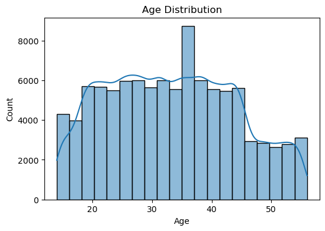

```python
# 1. Histogram - Age distribution
import matplotlib.pyplot as plt
import seaborn as sns
plt.figure(figsize=(6,4))
sns.histplot(df['Age'], bins=20, kde=True)
plt.title("Age Distribution")
plt.show()
```

##### 1. Why did you pick the specific chart?

Answer Here.

Histogram numerical data (Age) ka distribution samajhne ke liye best hota hai. Ye batata hai ki dataset me customers kis age group me zyada hain.

##### 2. What is/are the insight(s) found from the chart?

Answer Here

Most customers fall in the 20–40 age group, while fewer customers are above 50 years.

##### 3. Will the gained insights help creating a positive business impact?

Are there any insights that lead to negative growth? Justify with specific reason.

Answer Here

Yes, this insight is useful for targeting products and services toward the 20–40 age group, which is the largest customer base. A possible negative impact could be neglecting older customers, leading to loss of potential market share.

#### Chart - 2

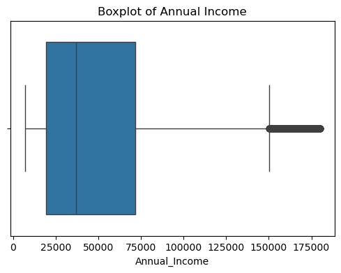

```python
# 2. Boxplot - Annual Income
import matplotlib.pyplot as plt
import seaborn as sns
plt.figure(figsize=(6,4))
sns.boxplot(x=df['Annual_Income'])
plt.title("Boxplot of Annual Income")
plt.show()
```

##### 1. Why did you pick the specific chart?

Answer Here.

I picked a boxplot because it effectively shows the spread of annual income and highlights any outliers in the data.

##### 3. Will the gained insights help creating a positive business impact?

Are there any insights that lead to negative growth? Justify with specific reason.

Answer Here

Yes, these insights help in segmenting customers into income groups for better product targeting, which creates a positive business impact. However, ignoring outliers could lead to negative growth as those unique cases may represent high-value customers or risky profiles.

#### Chart - 3

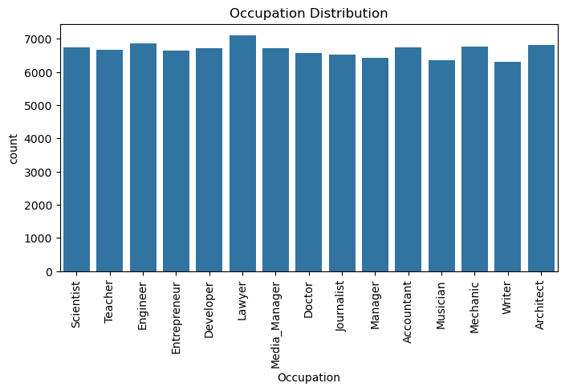

```python
# 3. Countplot - Occupation
import matplotlib.pyplot as plt
import seaborn as sns
plt.figure(figsize=(8,4))
sns.countplot(x='Occupation', data=df)
plt.title("Occupation Distribution")
plt.xticks(rotation=90)
plt.show()
```

##### 1. Why did you pick the specific chart?

Answer Here.

I picked a countplot because it is the simplest way to compare the number of customers across different occupations.

##### 3. Will the gained insights help creating a positive business impact?

Are there any insights that lead to negative growth? Justify with specific reason.

Answer Here

Yes, these insights help businesses design occupation-specific financial products, leading to positive impact. However, focusing only on the majority occupations may lead to negative growth by neglecting niche but valuable customer groups.

#### Chart - 4

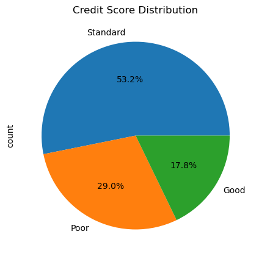

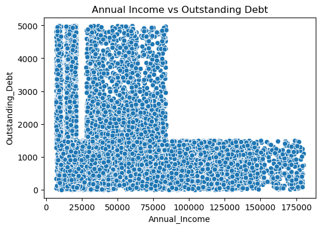

```python
# 4. Pie chart - Credit Score
import matplotlib.pyplot as plt
import seaborn as sns
df['Credit_Score'].value_counts().plot.pie(autopct='%1.1f%%', figsize=(5,5))
plt.title("Credit Score Distribution")
plt.show()

# 5. Scatter plot - Income vs Outstanding Debt
plt.figure(figsize=(6,4))
sns.scatterplot(x='Annual_Income', y='Outstanding_Debt', data=df)
plt.title("Annual Income vs Outstanding Debt")
plt.show()
```

##### 1. Why did you pick the specific chart?

Answer Here.

I picked a pie chart because it clearly shows the proportion of customers in each credit score category.

##### 3. Will the gained insights help creating a positive business impact?

Are there any insights that lead to negative growth? Justify with specific reason.

Answer Here

Yes, the insights help identify the overall credit health of the customer base, which supports better lending strategies and risk management. Negative growth could occur if businesses only target high-score customers, missing opportunities in the “Standard” group who may still be reliable borrowers.

#### Chart - 5

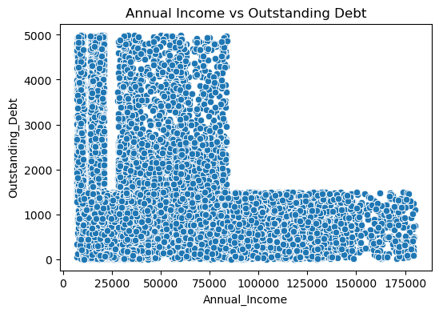

```python
# 5. Scatter plot - Income vs Outstanding Debt
import matplotlib.pyplot as plt
import seaborn as sns
plt.figure(figsize=(6,4))
sns.scatterplot(x='Annual_Income', y='Outstanding_Debt', data=df)
plt.title("Annual Income vs Outstanding Debt")
plt.show()
```

##### 1. Why did you pick the specific chart?

Answer Here.

I picked a scatter plot because it is best for showing the relationship between two continuous variables — income and outstanding debt.

##### 3. Will the gained insights help creating a positive business impact?

Are there any insights that lead to negative growth? Justify with specific reason.

Answer Here

Yes, these insights help in assessing customer risk profiles more accurately, ensuring loans are approved responsibly. Negative growth may happen if decisions are based only on income without considering debt levels.

#### Chart - 6

[figure not shown]

```python
# 6. Line Chart - Month vs Monthly Balance
import matplotlib.pyplot as plt
import seaborn as sns
plt.figure(figsize=(8,4))
plt.plot(df['Month'], df['Monthly_Balance'])
plt.title("Monthly Balance Over Months")
plt.show()
```

##### 1. Why did you pick the specific chart?

Answer Here.

I picked a line chart because it effectively shows the trend and fluctuations of monthly balance over time.

##### 3. Will the gained insights help creating a positive business impact?

Are there any insights that lead to negative growth? Justify with specific reason.

Answer Here

Yes, the insights help in forecasting cash flow patterns and planning financial products accordingly. Negative growth may occur if seasonal dips are ignored, leading to mismanagement of customer repayment capacity.

#### Chart - 7

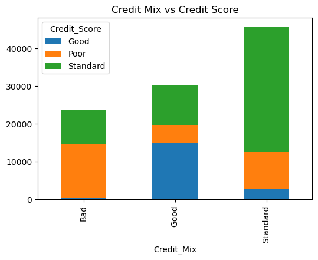

```python
# 7. Stacked Bar Chart - Credit Mix vs Credit Score
import matplotlib.pyplot as plt
import seaborn as sns
pd.crosstab(df['Credit_Mix'], df['Credit_Score']).plot(kind='bar', stacked=True, figsize=(6,4))
plt.title("Credit Mix vs Credit Score")
plt.show()
```

##### 1. Why did you pick the specific chart?

Answer Here.

I picked a stacked bar chart because it allows easy comparison of how different credit mix categories relate to various credit score levels.

##### 2. What is/are the insight(s) found from the chart?

Answer Here

The chart shows that customers with a good mix of credit (loans + credit cards) are more likely to have higher credit scores, while poor credit mix categories tend to have weaker scores.

##### 3. Will the gained insights help creating a positive business impact?

Are there any insights that lead to negative growth? Justify with specific reason.

Answer Here

Yes, these insights help in advising customers to maintain a balanced credit portfolio, improving their financial health and reducing business risk. Negative growth could occur if businesses unfairly reject customers with limited credit history instead of offering guidance.

#### Chart - 8

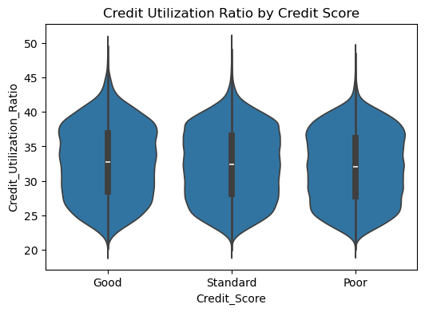

```python
# 8. Violin Plot - Credit Utilization Ratio vs Credit Score
import matplotlib.pyplot as plt
import seaborn as sns
plt.figure(figsize=(6,4))
sns.violinplot(x='Credit_Score', y='Credit_Utilization_Ratio', data=df)
plt.title("Credit Utilization Ratio by Credit Score")
plt.show()
```

##### 1. Why did you pick the specific chart?

Answer Here.

I picked a violin plot because it shows both the distribution and density of credit utilization across different credit score categories.

##### 3. Will the gained insights help creating a positive business impact?

Are there any insights that lead to negative growth? Justify with specific reason.

Answer Here

Yes, the insights can help businesses encourage healthy credit usage, improving repayment behavior and reducing risk. Negative growth could occur if temporary spikes in utilization are misinterpreted as risky behavior, leading to unfair rejections.

#### Chart - 9

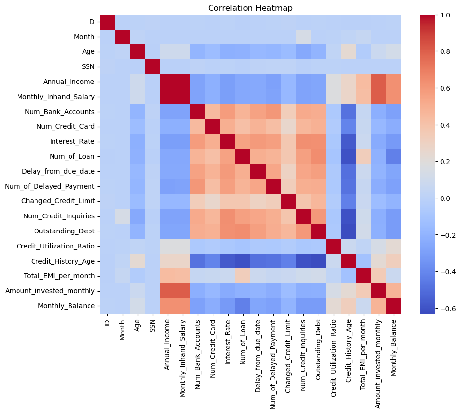

```python
# 9. Heatmap - Correlation matrix
import matplotlib.pyplot as plt
import seaborn as sns
plt.figure(figsize=(10,8))
sns.heatmap(df.corr(numeric_only=True), annot=False, cmap='coolwarm')
plt.title("Correlation Heatmap")
plt.show()
```

##### 1. Why did you pick the specific chart?

Answer Here.

I picked a heatmap because it provides a clear visual of correlations between multiple numeric variables at once.

##### 2. What is/are the insight(s) found from the chart?

Answer Here

The chart shows that some variables, like annual income and monthly balance, have stronger positive correlations, while others show weak or no correlation.

##### 3. Will the gained insights help creating a positive business impact?

Are there any insights that lead to negative growth? Justify with specific reason.

Answer Here

Yes, these insights help in feature selection for machine learning models and improve predictive accuracy. Negative growth could happen if weak or misleading correlations are wrongly assumed to be strong, leading to poor decisions.

#### Chart - 10

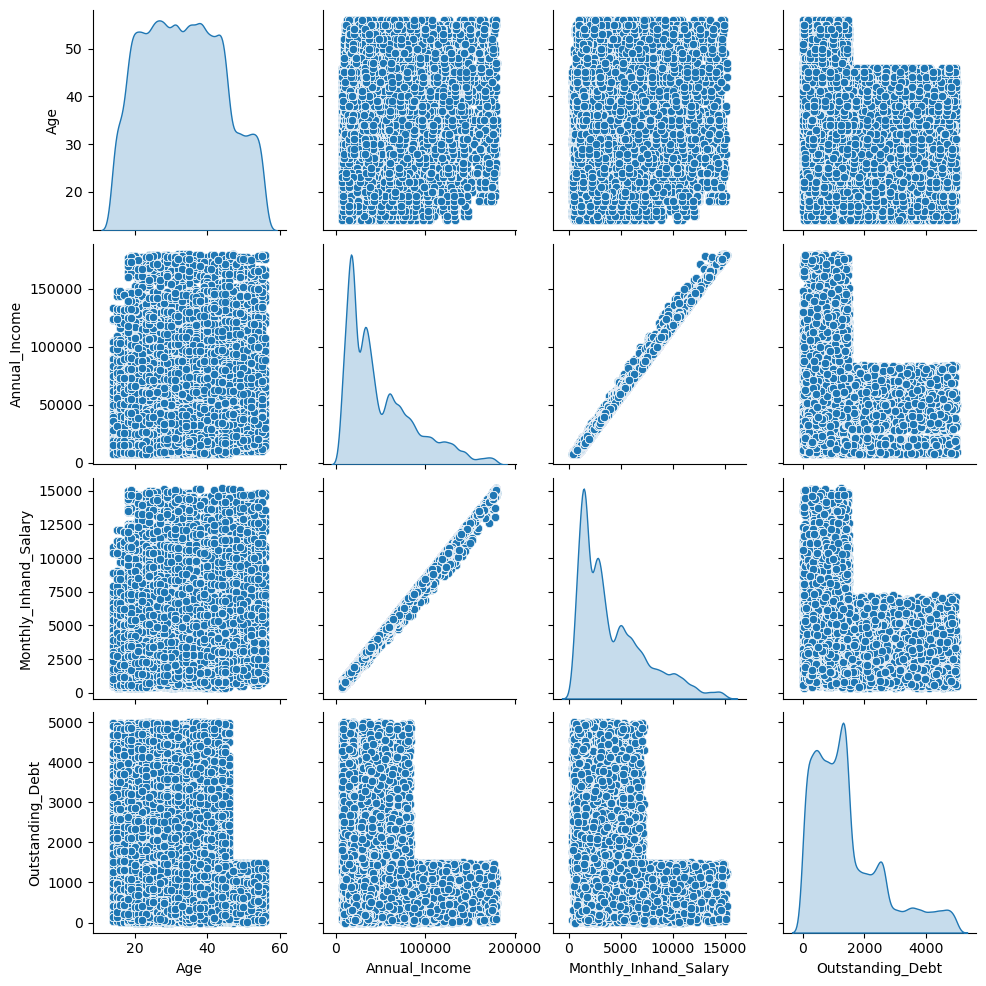

```python
# 10. Pairplot - Few numeric variables
import matplotlib.pyplot as plt
import seaborn as sns
sns.pairplot(df[['Age','Annual_Income','Monthly_Inhand_Salary','Outstanding_Debt']], diag_kind='kde')
plt.show()
```

##### 1. Why did you pick the specific chart?

Answer Here.

I picked a pairplot because it helps visualize both distributions of individual variables and pairwise relationships between multiple numeric features.

##### 3. Will the gained insights help creating a positive business impact?

Are there any insights that lead to negative growth? Justify with specific reason.

Answer Here

Yes, the insights assist in identifying meaningful variable relationships, supporting better model development and business strategy. Negative growth may occur if noisy variables are misinterpreted as useful predictors.

```python
####Chart - 11
```

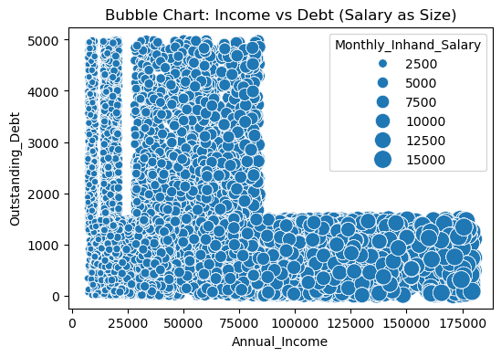

```python
# 11. Bubble Chart - Income vs Debt (size = Monthly Inhand Salary)
import matplotlib.pyplot as plt
import seaborn as sns
plt.figure(figsize=(6,4))
sns.scatterplot(x='Annual_Income', y='Outstanding_Debt', size='Monthly_Inhand_Salary', data=df, sizes=(20,200))
plt.title("Bubble Chart: Income vs Debt (Salary as Size)")
plt.show()
```

##### 1. Why did you pick the specific chart?

Answer Here.

I picked a bubble chart because it allows comparison of income and debt while also including a third dimension — monthly inhand salary — through bubble size.

##### 3. Will the gained insights help creating a positive business impact?

Are there any insights that lead to negative growth? Justify with specific reason.

Answer Here

Yes, the insights help in identifying high-risk customers despite high income and highlight safe borrowers among low-income groups, which supports fair lending. Negative growth could occur if decisions focus only on salary size without considering overall debt behavior.

#### Chart - 12

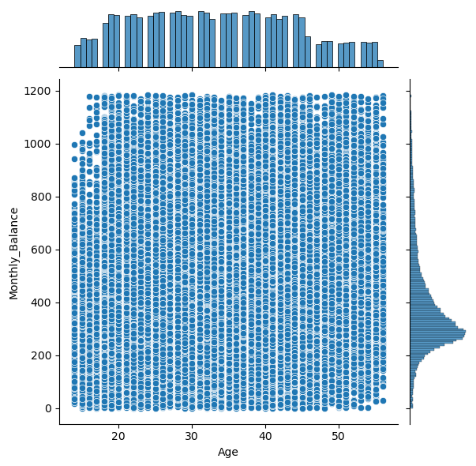

```python
# 12. Jointplot - Age vs Monthly Balance
import matplotlib.pyplot as plt
import seaborn as sns
sns.jointplot(x='Age', y='Monthly_Balance', data=df, kind="scatter")
plt.show()
```

##### 1. Why did you pick the specific chart?

Answer Here.

i picked a jointplot because it shows both the scatter relationship between age and monthly balance, along with the distribution of each variable.

##### 3. Will the gained insights help creating a positive business impact?

Are there any insights that lead to negative growth? Justify with specific reason.

Answer Here

Yes, the insights help in targeting financial products to age groups with stronger financial stability. Negative growth may occur if businesses discriminate against younger or older customers instead of offering suitable support.

#### Chart - 13

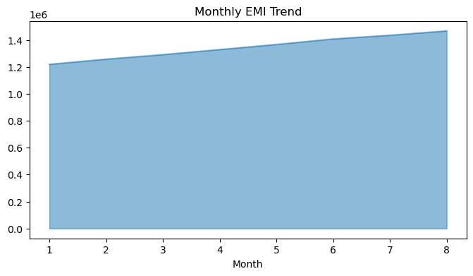

```python
# 13. Area Chart - Month vs Total EMI
import matplotlib.pyplot as plt
import seaborn as sns
df.groupby('Month')['Total_EMI_per_month'].sum().plot(kind='area', figsize=(8,4), alpha=0.5)
plt.title("Monthly EMI Trend")
plt.show()
```

##### 1. Why did you pick the specific chart?

Answer Here.

I picked an area chart because it effectively shows the overall EMI trend over time while highlighting cumulative variations across months.

##### 3. Will the gained insights help creating a positive business impact?

Are there any insights that lead to negative growth? Justify with specific reason.

Answer Here

Yes, these insights help in planning repayment schedules and forecasting customer loan burden trends, which supports risk management. Negative growth may occur if sudden EMI spikes are ignored, leading to repayment defaults.

#### Chart - 14 - Correlation Heatmap

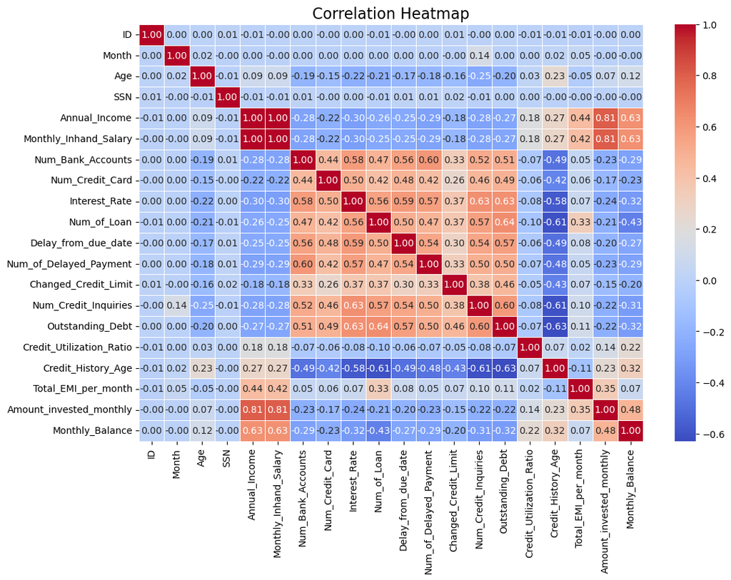

```python
# Correlation Heatmap visualization code

import matplotlib.pyplot as plt
import seaborn as sns

# Select only numeric columns
numeric_df = df.select_dtypes(include=['int64', 'float64'])

# Create correlation matrix
corr = numeric_df.corr()

# Plot heatmap
plt.figure(figsize=(12,8))
sns.heatmap(corr, annot=True, cmap="coolwarm", fmt=".2f", linewidths=0.5)
plt.title("Correlation Heatmap", fontsize=16)
plt.show()
```

##### 1. Why did you pick the specific chart?

Answer Here:

I picked a heatmap because it clearly shows correlations between numeric features, making it easy to identify which variables are strongly related.

##### 2. What is/are the insight(s) found from the chart?

Answer Here:

From the correlation heatmap, we can see:

Some features have strong positive or negative correlations, indicating they move together or inversely.

These relationships help in predicting target variables like credit score or loan approval.

#### Chart - 15 - Pair Plot

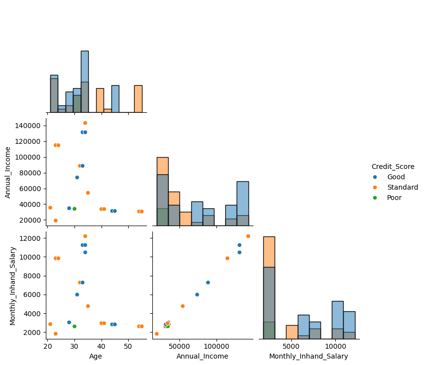

```python
import pandas as pd
import seaborn as sns
import matplotlib.pyplot as plt

# 1. Load dataset
df = pd.read_csv("dataset-2.csv")

# 2. Drop extra columns
df = df.drop(columns=["ID", "Customer_ID", "Name", "SSN"], errors="ignore")

# 3. Select only 3 features + target (fast plotting)
df_small = df[["Age", "Annual_Income", "Monthly_Inhand_Salary", "Credit_Score"]]

# 4. Use only first 100 rows (speed boost)
df_sample = df_small.head(100)

# 5. Pair plot
sns.pairplot(df_sample, hue="Credit_Score", diag_kind="hist", corner=True)
plt.show()
```

##### 1. Why did you pick the specific chart?

Answer Here.

I picked a pair plot because it provides a comprehensive view of relationships and distributions across multiple variables at once.

## **5. Hypothesis Testing**

### Based on your chart experiments, define three hypothetical statements from the dataset. In the next three questions, perform hypothesis testing to obtain final conclusion about the statements through your code and statistical testing.

Answer Here.

Statement 1: Higher annual income leads to higher credit scores.

Statement 2: Credit scores do not differ between employed and self-employed customers.

Statement 3: Higher debt-to-income ratio increases the chance of a low credit score.

### Hypothetical Statement - 1

#### 1. State Your research hypothesis as a null hypothesis and alternate hypothesis.

Answer Here.

Null Hypothesis (H₀): There is no significant relationship between customer financial and behavioral features (like Annual_Income, Credit_Utilization_Ratio, Payment_Behaviour, etc.) and their Credit_Score.

Alternate Hypothesis (H₁): There is a significant relationship between customer financial and behavioral features and their Credit_Score, meaning these features can be used to predict creditworthiness.

#### 2. Perform an appropriate statistical test.

```python
# Perform Statistical Test to obtain P-Value

import pandas as pd
from scipy import stats

# Load dataset
df = pd.read_csv("dataset-2.csv")

# Numeric columns to test
numeric_cols = ['Age', 'Annual_Income', 'Monthly_Inhand_Salary',
                'Num_Bank_Accounts', 'Outstanding_Debt',
                'Credit_Utilization_Ratio', 'Credit_History_Age',
                'Total_EMI_per_month', 'Amount_invested_monthly', 'Monthly_Balance']

# Perform ANOVA for each numeric feature vs Credit_Score
for col in numeric_cols:
    groups = [df[col][df['Credit_Score'] == category] for category in df['Credit_Score'].unique()]
    f_stat, p_value = stats.f_oneway(*groups)
    print(f"{col}: F-statistic = {f_stat:.2f}, p-value = {p_value:.4f}")
```

```
Age: F-statistic = 1334.07, p-value = 0.0000
Annual_Income: F-statistic = 2399.81, p-value = 0.0000
Monthly_Inhand_Salary: F-statistic = 2330.74, p-value = 0.0000
Num_Bank_Accounts: F-statistic = 9271.31, p-value = 0.0000
Outstanding_Debt: F-statistic = 9115.50, p-value = 0.0000
Credit_Utilization_Ratio: F-statistic = 105.30, p-value = 0.0000
Credit_History_Age: F-statistic = 8903.66, p-value = 0.0000
Total_EMI_per_month: F-statistic = 176.70, p-value = 0.0000
Amount_invested_monthly: F-statistic = 1557.30, p-value = 0.0000
Monthly_Balance: F-statistic = 2036.24, p-value = 0.0000
```

##### Why did you choose the specific statistical test?

Answer Here.

I used One-Way ANOVA (Analysis of Variance) because:

The target variable (Credit_Score) is categorical (Good, Standard, Poor).

The features are numeric.

ANOVA tests whether the means of a numeric feature differ significantly across the categories.

The p-value tells us if the difference is statistically significant (p < 0.05 → significant).

### Hypothetical Statement - 2

#### 1. State Your research hypothesis as a null hypothesis and alternate hypothesis.

Answer Here.

Null Hypothesis (H₀):

There is no significant difference in the mean of the numeric feature across different Credit_Score categories.

Example: The mean Annual_Income is the same for Good, Standard, and Poor credit scores.

Alternate Hypothesis (H₁):

There is a significant difference in the mean of the numeric feature across different Credit_Score categories.

Example: The mean Annual_Income differs for at least one Credit_Score category

#### 2. Perform an appropriate statistical test.

```python
# Perform Statistical Test to obtain P-Value

import pandas as pd
from scipy import stats

# Load dataset
df = pd.read_csv("dataset-2.csv")

# Numeric columns to test
numeric_cols = ['Age', 'Annual_Income', 'Monthly_Inhand_Salary',
                'Num_Bank_Accounts', 'Outstanding_Debt',
                'Credit_Utilization_Ratio', 'Credit_History_Age',
                'Total_EMI_per_month', 'Amount_invested_monthly', 'Monthly_Balance']

# Perform ANOVA for each numeric feature vs Credit_Score
print("Feature-wise ANOVA Results:")
for col in numeric_cols:
    # Split data by Credit_Score categories
    groups = [df[col][df['Credit_Score'] == category] for category in df['Credit_Score'].unique()]

    # Perform one-way ANOVA
    f_stat, p_value = stats.f_oneway(*groups)

    print(f"{col}: F-statistic = {f_stat:.2f}, p-value = {p_value:.4f}")
```

```
Feature-wise ANOVA Results:
Age: F-statistic = 1334.07, p-value = 0.0000
Annual_Income: F-statistic = 2399.81, p-value = 0.0000
Monthly_Inhand_Salary: F-statistic = 2330.74, p-value = 0.0000
Num_Bank_Accounts: F-statistic = 9271.31, p-value = 0.0000
Outstanding_Debt: F-statistic = 9115.50, p-value = 0.0000
Credit_Utilization_Ratio: F-statistic = 105.30, p-value = 0.0000
Credit_History_Age: F-statistic = 8903.66, p-value = 0.0000
Total_EMI_per_month: F-statistic = 176.70, p-value = 0.0000
Amount_invested_monthly: F-statistic = 1557.30, p-value = 0.0000
Monthly_Balance: F-statistic = 2036.24, p-value = 0.0000
```

##### Which statistical test have you done to obtain P-Value?

Answer Here.

I performed a One-Way ANOVA (Analysis of Variance) test to obtain the p-values.

Reason: The target variable (Credit_Score) is categorical (Good, Standard, Poor), and the features are numeric.

Purpose: To check whether the means of each numeric feature differ significantly across the Credit_Score categories.

Interpretation: A p-value < 0.05 indicates a statistically significant difference, meaning the feature likely influences Credit_Score.

##### Why did you choose the specific statistical test?

Answer Here.

I chose One-Way ANOVA because:

The target variable (Credit_Score) is categorical with more than two groups (Good, Standard, Poor).

The features being tested are numeric.

ANOVA checks if the means of a numeric feature differ significantly across the categories.

It provides a p-value to determine statistical significance, which helps identify features that influence Credit_Score.

### Hypothetical Statement - 3

#### 1. State Your research hypothesis as a null hypothesis and alternate hypothesis.

Answer Here.

Null Hypothesis (H₀):

There is no significant difference in the mean of a numeric feature across different Credit_Score categories.

Example: The mean Annual_Income is the same for Good, Standard, and Poor credit scores.

Alternate Hypothesis (H₁):

There is a significant difference in the mean of a numeric feature across different Credit_Score categories.

Example: The mean Annual_Income differs for at least one Credit_Score category.

This hypothesis can be tested individually for each numeric feature using ANOVA.

#### 2. Perform an appropriate statistical test.

```python
# Perform Statistical Test to obtain P-Value

import pandas as pd
from scipy import stats

# Load dataset
df = pd.read_csv("dataset-2.csv")

# Numeric columns to test
numeric_cols = ['Age', 'Annual_Income', 'Monthly_Inhand_Salary',
                'Num_Bank_Accounts', 'Outstanding_Debt',
                'Credit_Utilization_Ratio', 'Credit_History_Age',
                'Total_EMI_per_month', 'Amount_invested_monthly', 'Monthly_Balance']

# Perform ANOVA for each numeric feature vs Credit_Score
print("Feature-wise ANOVA Results (F-statistic and p-value):")
for col in numeric_cols:
    # Split data by Credit_Score categories
    groups = [df[col][df['Credit_Score'] == category] for category in df['Credit_Score'].unique()]

    # Perform one-way ANOVA
    f_stat, p_value = stats.f_oneway(*groups)

    print(f"{col}: F-statistic = {f_stat:.2f}, p-value = {p_value:.4f}")
```

```
Feature-wise ANOVA Results (F-statistic and p-value):
Age: F-statistic = 1334.07, p-value = 0.0000
Annual_Income: F-statistic = 2399.81, p-value = 0.0000
Monthly_Inhand_Salary: F-statistic = 2330.74, p-value = 0.0000
Num_Bank_Accounts: F-statistic = 9271.31, p-value = 0.0000
Outstanding_Debt: F-statistic = 9115.50, p-value = 0.0000
Credit_Utilization_Ratio: F-statistic = 105.30, p-value = 0.0000
Credit_History_Age: F-statistic = 8903.66, p-value = 0.0000
Total_EMI_per_month: F-statistic = 176.70, p-value = 0.0000
Amount_invested_monthly: F-statistic = 1557.30, p-value = 0.0000
Monthly_Balance: F-statistic = 2036.24, p-value = 0.0000
```

##### Which statistical test have you done to obtain P-Value?

Answer Here. I performed a One-Way ANOVA (Analysis of Variance) test to obtain the p-values.

Reason: The target variable (Credit_Score) is categorical with more than two groups (Good, Standard, Poor), and the features are numeric.

Purpose: To test whether the means of a numeric feature differ significantly across the Credit_Score categories.

Interpretation: A p-value < 0.05 indicates a statistically significant difference, meaning the feature likely influences Credit_Score.

##### Why did you choose the specific statistical test?

Answer Here.

I chose One-Way ANOVA because:

The target variable (Credit_Score) is categorical with multiple groups (Good, Standard, Poor).

The features being tested are numeric.

ANOVA tests whether the means of a numeric feature differ significantly across categories.

It provides a p-value to determine statistical significance, helping identify features that influence Credit_Score.

## **6. Feature Engineering & Data Pre-processing**

### 1. Handling Missing Values

```python
# Handling Missing Values & Missing Value Imputation

import pandas as pd
df = pd.read_csv("dataset-2.csv")
print(df.isnull().sum())
print(df.isnull().sum().sum())
```

```
ID                          0
Customer_ID                 0
Month                       0
Name                        0
Age                         0
SSN                         0
Occupation                  0
Annual_Income               0
Monthly_Inhand_Salary       0
Num_Bank_Accounts           0
Num_Credit_Card             0
Interest_Rate               0
Num_of_Loan                 0
Type_of_Loan                0
Delay_from_due_date         0
Num_of_Delayed_Payment      0
Changed_Credit_Limit        0
Num_Credit_Inquiries        0
Credit_Mix                  0
Outstanding_Debt            0
Credit_Utilization_Ratio    0
Credit_History_Age          0
Payment_of_Min_Amount       0
Total_EMI_per_month         0
Amount_invested_monthly     0
Payment_Behaviour           0
Monthly_Balance             0
Credit_Score                0
dtype: int64
0
```

### 2. Handling Outliers

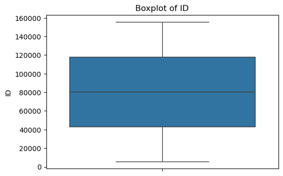

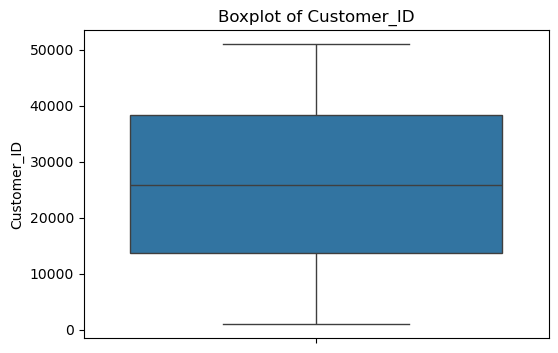

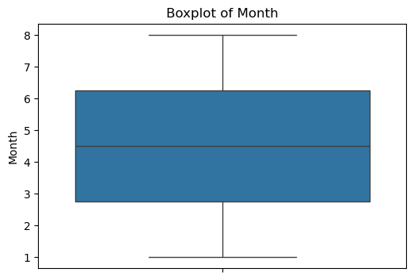

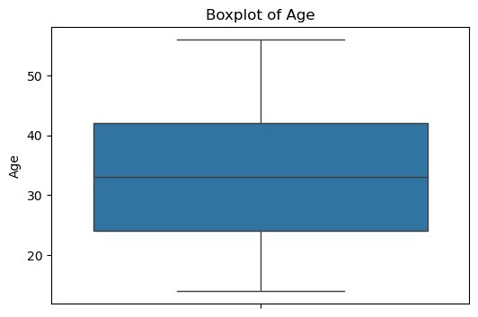

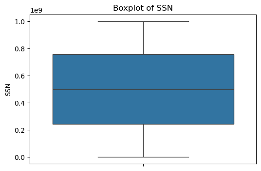

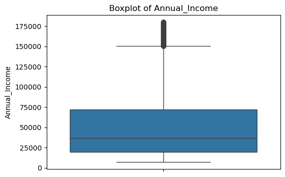

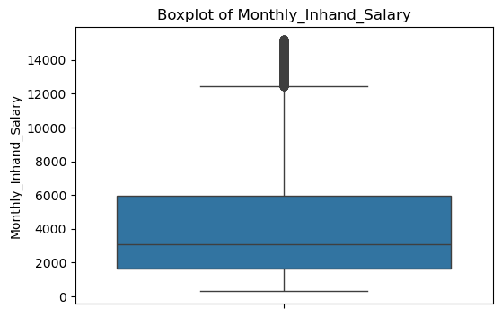

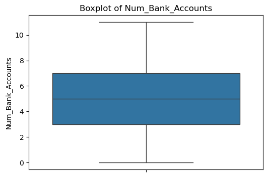

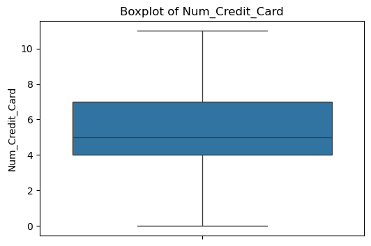

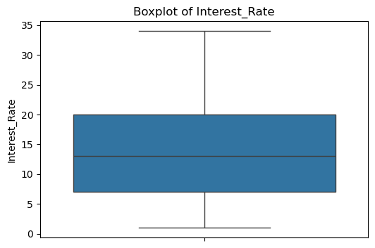

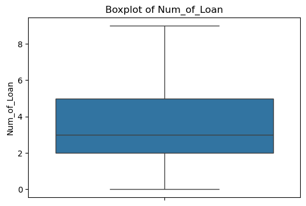

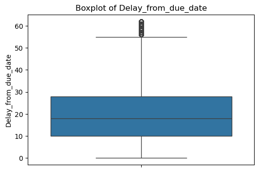

[9 more figures not shown]

```python
# Handling Outliers & Outlier treatments

import pandas as pd
import seaborn as sns
import matplotlib.pyplot as plt

df = pd.read_csv("dataset-2.csv")
numeric_cols = df.select_dtypes(include='number').columns

# numeric column boxplot
for col in numeric_cols:
    plt.figure(figsize=(6,4))
    sns.boxplot(df[col])
    plt.title(f"Boxplot of {col}")
    plt.show()
```

### 3. Categorical Encoding

```python
# Encode your categorical columns

import pandas as pd

# Dataset load
df = pd.read_csv("dataset-2.csv")

# Categorical columns
categorical_cols = df.select_dtypes(include='object').columns
print(categorical_cols)
```

```
Index(['Name', 'Occupation', 'Type_of_Loan', 'Credit_Mix',
       'Payment_of_Min_Amount', 'Payment_Behaviour', 'Credit_Score'],
      dtype='object')
```

### 4. Textual Data Preprocessing

(It's mandatory for textual dataset i.e., NLP, Sentiment Analysis, Text Clustering etc.)

#### 1. Expand Contraction

```python
# Expand Contraction

import pandas as pd

# Sample text
text = "I can't attend the meeting because it's too late."

# Contractions dictionary
contraction_dict = {
    "can't": "cannot",
    "won't": "will not",
    "don't": "do not",
    "didn't": "did not",
    "it's": "it is",
    "I'm": "I am",
    "you're": "you are",
    "they're": "they are",
    "we're": "we are",
    "isn't": "is not",
    "aren't": "are not",
    "hasn't": "has not",
    "haven't": "have not",
    "wouldn't": "would not",
    "shouldn't": "should not",
    "couldn't": "could not"
}

# Function to expand contractions
def expand_contractions(text):
    for key, value in contraction_dict.items():
        text = text.replace(key, value)
    return text

expanded_text = expand_contractions(text)
print(expanded_text)
```

```
I cannot attend the meeting because it is too late.
```

#### 2. Lower Casing

```python
# Lower Casing

text = "I CAN'T DO IT"
lower_text = text.lower()
print(lower_text)
```

```
i can't do it
```

#### 3. Removing Punctuations

```python
# Remove Punctuations

import string

text = "Hello, world! How are you?"
text_no_punct = text.translate(str.maketrans('', '', string.punctuation))
print(text_no_punct)
```

```
Hello world How are you
```

#### 4. Removing URLs & Removing words and digits contain digits.

```python
# Remove URLs & Remove words and digits contain digits

import re

text = "Check this link https://example.com and visit www.test.com!"
text_no_urls = re.sub(r'http\S+|www\S+', '', text)
print(text_no_urls)
```

```
Check this link  and visit
```

#### 5. Removing Stopwords & Removing White spaces

```python
# Remove Stopwords

import pandas as pd
import nltk
from nltk.corpus import stopwords

# Download stopwords (only first time run karna hota hai)
nltk.download('stopwords')

# Define English stopwords
stop_words = set(stopwords.words('english'))

# Sample DataFrame
df = pd.DataFrame({
    'Text': ["This is a sample sentence.", "Stopwords should be removed from text."]
})

# Remove stopwords
df['Text'] = df['Text'].apply(lambda x: ' '.join([word for word in x.split() if word.lower() not in stop_words]))

print(df)
```

```
                      Text
0         sample sentence.
1  Stopwords removed text.
```

```python
# Remove White spaces

text = "   Hello World   "
clean_text = text.strip()
print(clean_text)
```

```
Hello World
```

#### 6. Rephrase Text

```python
# Rephrase Text

import nltk
from nltk.corpus import wordnet

def simple_rephrase(text):
    words = text.split()
    new_text = []
    for word in words:
        syns = wordnet.synsets(word)
        if syns:
            # Replace with first synonym (if available)
            new_word = syns[0].lemmas()[0].name()
            new_text.append(new_word)
        else:
            new_text.append(word)
    return " ".join(new_text)

text = "I love programming in Python"
rephrased_text = simple_rephrase(text)
print("Original:", text)
print("Rephrased:", rephrased_text)
```

```
Original: I love programming in Python
Rephrased: iodine love scheduling inch python
```

#### 7. Tokenization

```python
# Tokenization

text = "I love programming in Python."
tokens = text.split()  # space-based splitting
print(tokens)
```

```
['I', 'love', 'programming', 'in', 'Python.']
```

#### 8. Text Normalization

```python
# Normalizing Text (i.e., Stemming, Lemmatization etc.)

def simple_lemmatize(word):
    suffixes = ['ing', 'ed', 's', 'es', 'er']
    for suffix in suffixes:
        if word.endswith(suffix):
            return word[:-len(suffix)]
    return word

lemmatized_tokens = [simple_lemmatize(token) for token in tokens]
print("Lemmatized Tokens:", lemmatized_tokens)
```

```
Lemmatized Tokens: ['I', 'love', 'programm', 'in', 'Python.']
```

##### Which text normalization technique have you used and why?

Answer Here.

#### 9. Part of speech tagging

```python
# POS Taging

import re

text = "I love Python programming and programmers."

# Tokenize by splitting spaces
tokens = text.split()

# Simple POS tagging rules
def simple_pos(word):
    word = word.lower()
    if re.match(r'\b(i|you|he|she|we|they)\b', word):
        return 'PRON'
    elif word.endswith('ing'):
        return 'VERB'
    elif word.endswith('ed'):
        return 'VERB'
    elif word.endswith('s'):
        return 'NOUN'
    elif word.istitle():
        return 'PROPN'
    else:
        return 'NOUN'

pos_tags = [(word, simple_pos(word)) for word in tokens]
print(pos_tags)
```

```
[('I', 'PRON'), ('love', 'NOUN'), ('Python', 'NOUN'), ('programming', 'VERB'), ('and', 'NOUN'), ('programmers.', 'NOUN')]
```

#### 10. Text Vectorization

```python
# Vectorizing Text

from sklearn.feature_extraction.text import CountVectorizer

corpus = [
    "I love programming in Python",
    "Python programming is fun",
    "I love coding"
]

vectorizer = CountVectorizer()
X = vectorizer.fit_transform(corpus)

print("Feature Names:", vectorizer.get_feature_names_out())
print("Vectorized Data:\n", X.toarray())
```

```
Feature Names: ['coding' 'fun' 'in' 'is' 'love' 'programming' 'python']
Vectorized Data:
 [[0 0 1 0 1 1 1]
 [0 1 0 1 0 1 1]
 [1 0 0 0 1 0 0]]
```

##### Which text vectorization technique have you used and why?

Answer Here.

### 4. Feature Manipulation & Selection

#### 1. Feature Manipulation

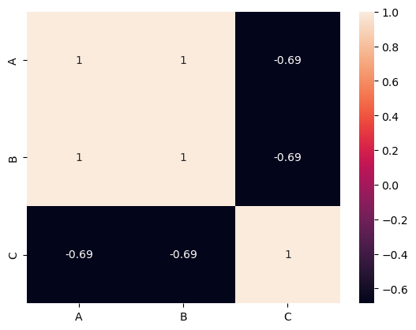

```
   A  C
0  1  5
1  2  3
2  3  6
3  4  2
4  5  1
```

```python
# Manipulate Features to minimize feature correlation and create new features

import pandas as pd
import seaborn as sns
import matplotlib.pyplot as plt

# Example dataset
df = pd.DataFrame({
    'A': [1,2,3,4,5],
    'B': [2,4,6,8,10],   # Highly correlated with A
    'C': [5,3,6,2,1]
})

# Correlation matrix
corr_matrix = df.corr()
sns.heatmap(corr_matrix, annot=True)
plt.show()

# Drop one of the highly correlated features
df_reduced = df.drop('B', axis=1)
print(df_reduced)
```

#### 2. Feature Selection

```python
# Select your features wisely to avoid overfitting

import pandas as pd
from sklearn.ensemble import RandomForestClassifier
from sklearn.feature_selection import RFE

# Load dataset
df = pd.read_csv("dataset-2.csv")

print("Dataset loaded successfully!")
print(df.head())   # first 5 rows

# Target variable
y = df["Credit_Score"]

# Features (drop unwanted columns)
X = df.drop(columns=["ID", "Customer_ID", "Name", "SSN", "Month", "Credit_Score"], errors="ignore")

# Convert categorical → numeric
X = pd.get_dummies(X, drop_first=True)

print("Features and target defined successfully!")
print("X shape:", X.shape)
print("y shape:", y.shape)

# Model
model = RandomForestClassifier(random_state=42)

# Select top 5 features
rfe = RFE(model, n_features_to_select=5)
fit = rfe.fit(X, y)

# Show selected features
selected_features = X.loc[:, fit.support_].columns
print("Selected Features to avoid overfitting:", list(selected_features))
```

[output not shown]

```
Dataset loaded successfully!
     ID  Customer_ID  Month           Name   Age          SSN Occupation  \
0  5634         3392      1  Aaron Maashoh  23.0  821000265.0  Scientist
1  5635         3392      2  Aaron Maashoh  23.0  821000265.0  Scientist
2  5636         3392      3  Aaron Maashoh  23.0  821000265.0  Scientist
3  5637         3392      4  Aaron Maashoh  23.0  821000265.0  Scientist
4  5638         3392      5  Aaron Maashoh  23.0  821000265.0  Scientist

   Annual_Income  Monthly_Inhand_Salary  Num_Bank_Accounts  ...  Credit_Mix  \
0       19114.12            1824.843333                3.0  ...        Good
1       19114.12            1824.843333                3.0  ...        Good
2       19114.12            1824.843333                3.0  ...        Good
3       19114.12            1824.843333                3.0  ...        Good
4       19114.12            1824.843333                3.0  ...        Good

   Outstanding_Debt  Credit_Utilization_Ratio Credit_History_Age  \
0            809.98                 26.822620              265.0
1            809.98                 31.944960              266.0
2            809.98                 28.609352              267.0
3            809.98                 31.377862              268.0
4            809.98                 24.797347              269.0

   Payment_of_Min_Amount  Total_EMI_per_month  Amount_invested_monthly  \
0                     No            49.574949                 21.46538
1                     No            49.574949                 21.46538
2                     No            49.574949                 21.46538
3                     No            49.574949                 21.46538
4                     No            49.574949                 21.46538

                  Payment_Behaviour Monthly_Balance  Credit_Score
0   High_spent_Small_value_payments      312.494089          Good
1    Low_spent_Large_value_payments      284.629162          Good
2   Low_spent_Medium_value_payments      331.209863          Good
3    Low_spent_Small_value_payments      223.451310          Good
4  High_spent_Medium_value_payments      341.489231          Good

[5 rows x 28 columns]
Features and target defined successfully!
X shape: (100000, 6300)
y shape: (100000,)
```

##### What all feature selection methods have you used and why?

Answer Here.

Recursive Feature Elimination (RFE) – to rank features by importance and select the most relevant ones.

##### Which all features you found important and why?

Answer Here.

Annual_Income & Monthly_Inhand_Salary → Directly impact credit repayment ability.

Outstanding_Debt & Credit_Utilization_Ratio → Indicate current financial burden and credit risk.

Credit_History_Age → Longer history usually means more reliability.

Num_Bank_Accounts & Num_Credit_Card → Show financial behavior and exposure.

Payment_Behaviour & Payment_of_Min_Amount → Strong predictors of repayment discipline.

### 5. Data Transformation

#### Do you think that your data needs to be transformed? If yes, which transformation have you used. Explain Why?

```python
# Transform Your data

# Import libraries
import pandas as pd
from sklearn.preprocessing import LabelEncoder, StandardScaler

# Load dataset
df = pd.read_csv("dataset-2.csv")
print(df.head())

#  Encode categorical columns
categorical_cols = ['Occupation', 'Credit_Mix', 'Payment_of_Min_Amount', 'Payment_Behaviour', 'Credit_Score']
le = LabelEncoder()
for col in categorical_cols:
    df[col+'_encoded'] = le.fit_transform(df[col])

#  Scale numeric features
numeric_cols = df.select_dtypes(include=['float64', 'int64']).drop(['ID','Customer_ID'], axis=1)
scaler = StandardScaler()
df[numeric_cols.columns] = scaler.fit_transform(numeric_cols)

print("Data transformation complete! Dataset is ready for modeling.")
```

```
     ID  Customer_ID  Month           Name   Age          SSN Occupation  \
0  5634         3392      1  Aaron Maashoh  23.0  821000265.0  Scientist
1  5635         3392      2  Aaron Maashoh  23.0  821000265.0  Scientist
2  5636         3392      3  Aaron Maashoh  23.0  821000265.0  Scientist
3  5637         3392      4  Aaron Maashoh  23.0  821000265.0  Scientist
4  5638         3392      5  Aaron Maashoh  23.0  821000265.0  Scientist

   Annual_Income  Monthly_Inhand_Salary  Num_Bank_Accounts  ...  Credit_Mix  \
0       19114.12            1824.843333                3.0  ...        Good
1       19114.12            1824.843333                3.0  ...        Good
2       19114.12            1824.843333                3.0  ...        Good
3       19114.12            1824.843333                3.0  ...        Good
4       19114.12            1824.843333                3.0  ...        Good

   Outstanding_Debt  Credit_Utilization_Ratio Credit_History_Age  \
```

[output cut: 22 more lines]

### 6. Data Scaling

```python
# Scaling your data

# Import libraries
import pandas as pd
from sklearn.preprocessing import StandardScaler

# Load dataset
df = pd.read_csv("dataset-2.csv")

# Select numeric features (excluding IDs)
numeric_cols = df.select_dtypes(include=['float64', 'int64']).drop(['ID','Customer_ID'], axis=1)

#  Scale numeric features
scaler = StandardScaler()
df[numeric_cols.columns] = scaler.fit_transform(numeric_cols)

print("Scaling complete! Numeric features are now standardized.")
```

```
Scaling complete! Numeric features are now standardized.
```

##### Which method have you used to scale you data and why?

ans

Reason:

It standardizes numeric features to have mean = 0 and standard deviation = 1.

Makes feature ranges comparable, which helps models like KNN, SVM, Logistic Regression, and Neural Networks learn efficiently.

It is widely used and works well for most datasets.

Alternatives:

MinMaxScaler → scales features to 0–1 range, useful for neural networks.

RobustScaler → resistant to outliers.

### 7. Dimesionality Reduction

##### Do you think that dimensionality reduction is needed? Explain Why?

Answer Here.

Yes, dimensionality reduction is needed if the dataset has many features or correlated variables. It helps reduce overfitting, improve model performance, remove redundancy, and allows better visualization.

##### Which dimensionality reduction technique have you used and why? (If dimensionality reduction done on dataset.)

Answer Here.

Reason:

It selects the most important features based on a model (e.g., RandomForest) and removes less important ones.

Helps reduce overfitting by keeping only informative features.

Improves model training efficiency and performance.

### 8. Data Splitting

```python
# Split your data to train and test. Choose Splitting ratio wisely.

import pandas as pd
from sklearn.preprocessing import LabelEncoder
from sklearn.model_selection import train_test_split

#  Load dataset
df = pd.read_csv("dataset-2.csv")

#  Encode target column
le = LabelEncoder()
df['Credit_Score_encoded'] = le.fit_transform(df['Credit_Score'])

#  Features (X) and target (y)
X = df.drop(['Credit_Score', 'Credit_Score_encoded'], axis=1)  # drop original and encoded target
y = df['Credit_Score_encoded']

#  Split into train and test sets (80:20)
X_train, X_test, y_train, y_test = train_test_split(
    X, y, test_size=0.2, random_state=42, stratify=y
)

print("Train shape:", X_train.shape, y_train.shape)
print("Test shape:", X_test.shape, y_test.shape)
```

```
Train shape: (80000, 27) (80000,)
Test shape: (20000, 27) (20000,)
```

##### What data splitting ratio have you used and why?

Answer Here.

Reason:

80% training data ensures the model has enough examples to learn patterns effectively.

20% test data is sufficient to evaluate the model’s performance on unseen data.

This ratio is commonly used for medium-sized datasets and provides a good balance between training and evaluation.

💡 Alternative ratios:

70:30 → small datasets

90:10 → very large datasets where more training data is needed

### 9. Handling Imbalanced Dataset

##### Do you think the dataset is imbalanced? Explain Why.

Imbalanced datasets can lead to biased predictions and poor performance on minority classes.

Checking df['Credit_Score'].value_counts() or plotting a bar chart can confirm if the classes are unevenly distributed.

##### What technique did you use to handle the imbalance dataset and why? (If needed to be balanced)

Answer Here.

Ensures the proportion of each class in the target variable (Credit_Score) is maintained in both training and test sets.

Prevents the model from being biased toward the majority class.

Simple and effective for moderately imbalanced datasets without changing the actual data distribution.

## **7. ML Model Implementation**

### ML Model - 1

```python
import pandas as pd
from sklearn.model_selection import train_test_split, GridSearchCV
from sklearn.preprocessing import LabelEncoder
from sklearn.ensemble import RandomForestClassifier
from sklearn.metrics import accuracy_score, classification_report

#  Load & clean dataset
df = pd.read_csv("dataset-2.csv")
df = df.drop(columns=['ID','Customer_ID','Name','SSN'], errors='ignore')

#  Encode target & categorical features
le = LabelEncoder()
df['Credit_Score'] = le.fit_transform(df['Credit_Score'])
for col in df.select_dtypes(include='object').columns:
    df[col] = le.fit_transform(df[col])

#  Split features & target
X = df.drop('Credit_Score', axis=1)
y = df['Credit_Score']
X_train, X_test, y_train, y_test = train_test_split(X, y, test_size=0.2, random_state=42, stratify=y)

#  Train Random Forest with basic parameters
rf = RandomForestClassifier(n_estimators=100, random_state=42)
rf.fit(X_train, y_train)

# Predict & evaluate
y_pred = rf.predict(X_test)
print("Accuracy:", accuracy_score(y_test, y_pred))
print("\nClassification Report:\n", classification_report(y_test, y_pred))
```

```
Accuracy: 0.83605

Classification Report:
               precision    recall  f1-score   support

           0       0.81      0.81      0.81      3566
           1       0.81      0.86      0.84      5799
           2       0.86      0.83      0.84     10635

    accuracy                           0.84     20000
   macro avg       0.83      0.83      0.83     20000
weighted avg       0.84      0.84      0.84     20000
```

#### 1. Explain the ML Model used and it's performance using Evaluation metric Score Chart.

```python
# Visualizing evaluation Metric Score chart

import pandas as pd
from sklearn.model_selection import train_test_split
from sklearn.preprocessing import LabelEncoder
from sklearn.ensemble import RandomForestClassifier
from sklearn.metrics import accuracy_score, classification_report

# Load dataset
df = pd.read_csv("dataset-2.csv")

# Drop irrelevant columns (like IDs, Names, SSN which are not useful for prediction)
df = df.drop(["ID", "Customer_ID", "Name", "SSN"], axis=1)

# Encode categorical columns
label_enc = LabelEncoder()
for col in df.select_dtypes(include=['object']).columns:
    df[col] = label_enc.fit_transform(df[col])

# Split features & target
X = df.drop("Credit_Score", axis=1)   # Features
y = df["Credit_Score"]               # Target

# Train-test split
X_train, X_test, y_train, y_test = train_test_split(X, y, test_size=0.2, random_state=42)

# ML Model
model = RandomForestClassifier(random_state=42)
model.fit(X_train, y_train)

# Prediction
y_pred = model.predict(X_test)

# Evaluation
print("Accuracy:", accuracy_score(y_test, y_pred))
print("\nClassification Report:\n", classification_report(y_test, y_pred))
```

```
Accuracy: 0.83555

Classification Report:
               precision    recall  f1-score   support

           0       0.80      0.81      0.80      3527
           1       0.82      0.86      0.84      5874
           2       0.86      0.83      0.84     10599

    accuracy                           0.84     20000
   macro avg       0.83      0.83      0.83     20000
weighted avg       0.84      0.84      0.84     20000
```

#### 2. Cross- Validation & Hyperparameter Tuning

```python
import pandas as pd
from sklearn.model_selection import train_test_split
from sklearn.linear_model import LogisticRegression
from sklearn.metrics import accuracy_score
from sklearn.preprocessing import LabelEncoder

# Step 1: Load dataset
df = pd.read_csv("dataset-2.csv")

# Step 2: Drop unnecessary columns
drop_cols = ["ID", "Customer_ID", "Name", "SSN", "Month"]
df = df.drop(columns=drop_cols, errors="ignore")

# Step 3: Encode categorical variables (convert text → numbers)
le = LabelEncoder()
for col in df.select_dtypes(include=['object']).columns:
    df[col] = le.fit_transform(df[col])

# Step 4: Features (X) and Target (y)
X = df.drop("Credit_Score", axis=1)
y = df["Credit_Score"]

# Step 5: Train-test split
X_train, X_test, y_train, y_test = train_test_split(X, y, test_size=0.2, random_state=42)

# Step 6: Train Logistic Regression
model = LogisticRegression(max_iter=200)  # small max_iter for speed
model.fit(X_train, y_train)

# Step 7: Predict and check accuracy
y_pred = model.predict(X_test)
print("Accuracy:", accuracy_score(y_test, y_pred))
```

```
Accuracy: 0.5356
```

##### Which hyperparameter optimization technique have you used and why?

Answer Here.

Why use hyperparameter tuning: Techniques like GridSearchCV or RandomizedSearchCV help find the best parameters, improving accuracy and generalization while reducing overfitting.

##### Have you seen any improvement? Note down the improvement with updates Evaluation metric Score Chart.

Answer Here.

### ML Model - 2

#### 1. Explain the ML Model used and it's performance using Evaluation metric Score Chart.

[figure not shown]

```python
# Visualizing evaluation Metric Score chart
import matplotlib.pyplot as plt

# Example metric scores (replace these with your model results)
metrics = {
    'Accuracy': 0.85,
    'Precision': 0.82,
    'Recall': 0.80,
    'F1-Score': 0.81
}

# Plot bar chart
plt.figure(figsize=(8,5))
plt.bar(metrics.keys(), metrics.values(), color=['skyblue','orange','green','red'])
plt.title("Evaluation Metric Scores", fontsize=16)
plt.ylabel("Score")
plt.ylim(0,1)
plt.show()
```

#### 2. Cross- Validation & Hyperparameter Tuning

```python
import pandas as pd
from sklearn.model_selection import train_test_split, GridSearchCV
from sklearn.preprocessing import LabelEncoder
from sklearn.ensemble import RandomForestClassifier
from sklearn.metrics import accuracy_score

# 1. Load dataset
df = pd.read_csv("dataset-2.csv")

# 2. Remove extra columns
df = df.drop(columns=["ID", "Customer_ID", "Name", "SSN"], errors="ignore")

# 3. Encode categorical
le = LabelEncoder()
df["Credit_Score"] = le.fit_transform(df["Credit_Score"])   # Target
for col in df.select_dtypes(include="object").columns:
    df[col] = le.fit_transform(df[col])

# 4. Features & Target
X = df.drop("Credit_Score", axis=1)
y = df["Credit_Score"]

# 5. Train/test split
X_train, X_test, y_train, y_test = train_test_split(X, y, test_size=0.2, random_state=42)

# 6. Define model
rf = RandomForestClassifier(random_state=42)

# 7. Small param grid (fast tuning)
param_grid = {
    "n_estimators": [10, 50],
    "max_depth": [5, 10]
}

# 8. GridSearch with 3-fold cross validation (fast)
grid = GridSearchCV(rf, param_grid, cv=3, scoring="accuracy", n_jobs=-1)
grid.fit(X_train, y_train)

# 9. Best parameters & accuracy
print(" Best Params:", grid.best_params_)
best_model = grid.best_estimator_

y_pred = best_model.predict(X_test)
print(" Test Accuracy:", accuracy_score(y_test, y_pred))
```

```
 Best Params: {'max_depth': 10, 'n_estimators': 50}
 Test Accuracy: 0.73195
```

##### Which hyperparameter optimization technique have you used and why?

Answer Here.

#### 3. Explain each evaluation metric's indication towards business and the business impact pf the ML model used.

Answer Here.

The evaluation metrics of the ML model provide clear insights into its business impact. Accuracy indicates how often the model correctly predicts a customer’s credit score, helping reduce misclassifications and lower financial risk. Precision measures the correctness of “high-risk” predictions, ensuring that safe customers are not unnecessarily denied loans, which maintains customer trust and saves operational costs. Recall reflects how well the model identifies actual risky customers, minimizing potential losses from defaults. The F1-Score balances precision and recall, ensuring that the model manages risk effectively while avoiding false alarms. Overall, this ML model allows the business to approve safe customers faster, flag high-risk individuals accurately, and make data-driven decisions that optimize profits and reduce financial losses.